# Bayesian Analyses for Social Development

Rebekah Gelpi

12/09/2020

## Introduction to data

This introduction to Bayesian hypothesis testing uses the `BayesFactor` package in R as well as the dataset from the package `palmerpenguins`. First, the data will be loaded into R.

```r
data(penguins)
summary(penguins)
```

```
##       species          island    bill_length_mm  bill_depth_mm
##  Adelie   :152   Biscoe   :168   Min.   :32.10   Min.   :13.10
##  Chinstrap: 68   Dream    :124   1st Qu.:39.23   1st Qu.:15.60
##  Gentoo   :124   Torgersen: 52   Median :44.45   Median :17.30
##                                  Mean   :43.92   Mean   :17.15
##                                  3rd Qu.:48.50   3rd Qu.:18.70
##                                  Max.   :59.60   Max.   :21.50
##                                  NA's   :2       NA's   :2
##  flipper_length_mm  body_mass_g       sex           year
##  Min.   :172.0     Min.   :2700   female:165   Min.   :2007
##  1st Qu.:190.0     1st Qu.:3550   male  :168   1st Qu.:2007
##  Median :197.0     Median :4050   NA's  : 11   Median :2008
##  Mean   :200.9     Mean   :4202                Mean   :2008
##  3rd Qu.:213.0     3rd Qu.:4750                3rd Qu.:2009
##  Max.   :231.0     Max.   :6300                Max.   :2009
##  NA's   :2         NA's   :2
```

## Visualizations

The presentation covered two basic hypotheses: one that bill length varied by sex and one that it varied by species and sex. Using `ggplot2`, this data can be represented visually. First, the data by sex alone:

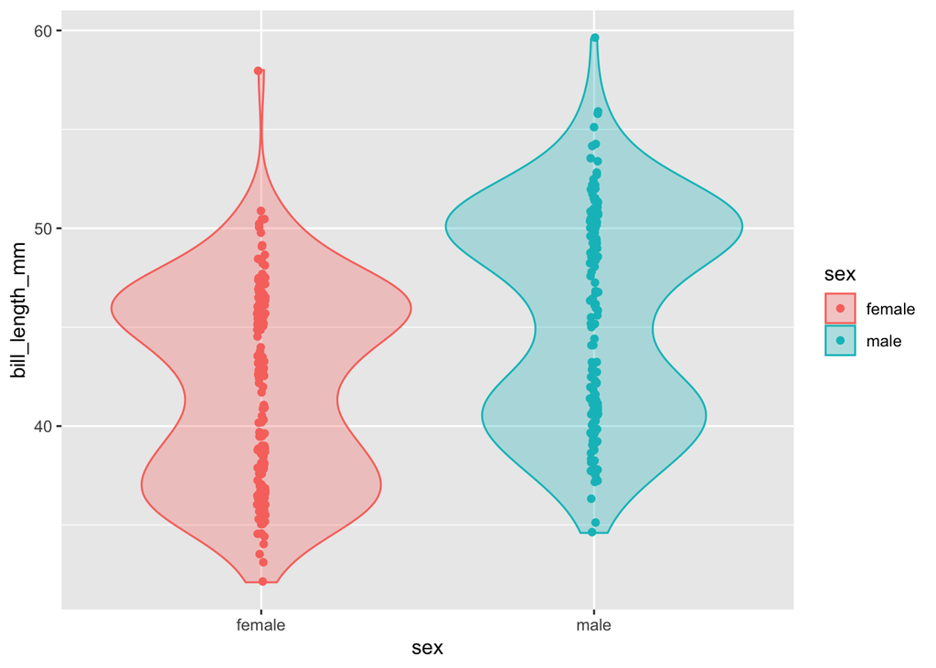

```r
penguins %>% drop_na() %>% ggplot(aes(x = sex, y = bill_length_mm, colour = sex, fill = sex)) +
  geom_jitter(position = position_jitterdodge(
    jitter.width = 0.05,
    jitter.height = 0.05,
    dodge.width = 0.9)) +
  geom_violin(alpha = 0.3)
```

Next, the data by sex and species:

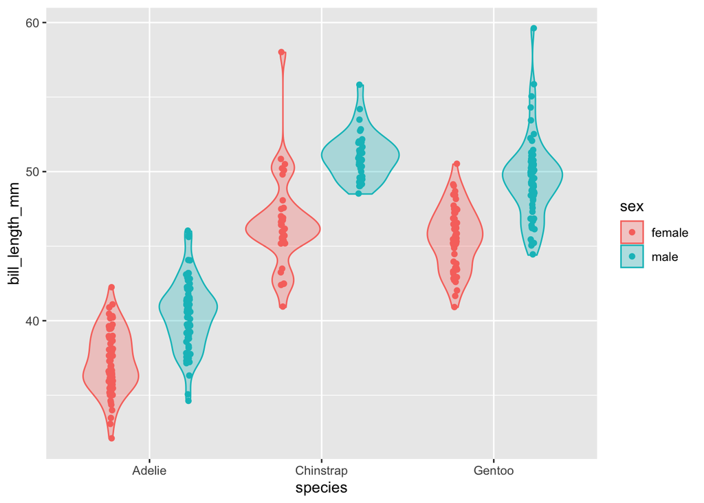

```r
penguins %>% drop_na() %>% ggplot(aes(x = species, y = bill_length_mm, colour = sex, fill = sex)) +
  geom_jitter(position = position_jitterdodge(
    jitter.width = 0.05,
    jitter.height = 0.05,
    dodge.width = 0.9)) +
  geom_violin(alpha = 0.3)
```

## Bayes factor

We can visually identify a difference in both cases, but to be sure, this requires some statistical analyses. First, a Bayesian independent sample t-test using the default JZS priors included in `BayesFactor`.

```r
bf = penguins %>% drop_na() %>% ttestBF(formula = bill_length_mm ~ sex, data = .)
bf
```

```
## Bayes factor analysis
## --------------
## [1] Alt., r=0.707 : 73446825 ±0%
##
## Against denominator:
##   Null, mu1-mu2 = 0
## ---
## Bayes factor type: BFindepSample, JZS
```

The Bayesian t-test provides strong evidence for the alternative (BF = 73446825). This can also be done with multiple comparisons (such as for species and sex), although this requires using a Bayesian ANOVA:

```r
bf2 = penguins %>% drop_na() %>% anovaBF(formula = bill_length_mm ~ sex + species + sex:species, data = .)
bf2/max(bf2)
```

```
## Bayes factor analysis
## --------------
## [1] species                     : 2.484191e-34  ±1.6%
## [2] sex                         : 2.794455e-111 ±1.6%
## [3] species + sex               : 1             ±0%
## [4] species + sex + species:sex : 0.4267547     ±3.4%
##
## Against denominator:
##   bill_length_mm ~ species + sex
## ---
## Bayes factor type: BFlinearModel, JZS
```

Using `max(bf2)` to compare against the best model, this finds that the `species + sex` model without the interaction effect is highly credible relative to a species-only or sex-only model. The data favours the no-interaction model relative to the interaction model, BF = 0.4, but this value is inconclusive and serves as only anecdotal evidence in favour of the no-interaction model.

## Posterior estimation

Next, parameter estimates can be calculated using the `posterior` function. This draws 10,000 samples using a Markov chain Monte Carlo (MCMC) algorithm to approximate the posterior distribution.

```r
chains = posterior(model = bf, iterations = 10000, progress=FALSE)
summary(chains)
```

```
##
## Iterations = 1:10000
## Thinning interval = 1
## Number of chains = 1
## Sample size per chain = 10000
##
## 1. Empirical mean and standard deviation for each variable,
##    plus standard error of the mean:
##
##                         Mean      SD Naive SE Time-series SE
## mu                   43.9800  0.2883 0.002883       0.002970
## beta (female - male) -3.6670  0.5699 0.005699       0.005991
## sig2                 26.6705  2.0742 0.020742       0.021815
## delta                -0.7117  0.1139 0.001139       0.001254
## g                     3.8777 33.1257 0.331257       0.367298
##
## 2. Quantiles for each variable:
##
##                         2.5%     25%     50%     75%   97.5%
## mu                   43.4256 43.7849 43.9803 44.1739 44.5517
## beta (female - male) -4.7753 -4.0523 -3.6787 -3.2772 -2.5477
## sig2                 22.9082 25.2173 26.5830 28.0316 31.0096
## delta                -0.9333 -0.7891 -0.7135 -0.6337 -0.4883
## g                     0.1313  0.3506  0.7149  1.7278 18.6592
```

Note: these numbers don’t necessary line up perfectly against those shown in the presentation because every MCMC chain is unique. In the limit, however, as more samples are drawn, the numbers generated should converge closer and closer together.

The credible interval for the difference measured here, `beta`, is represented as one of the matrices in the `chains` object. A visualization of the quantiles represented here can be drawn by simply plotting the object:

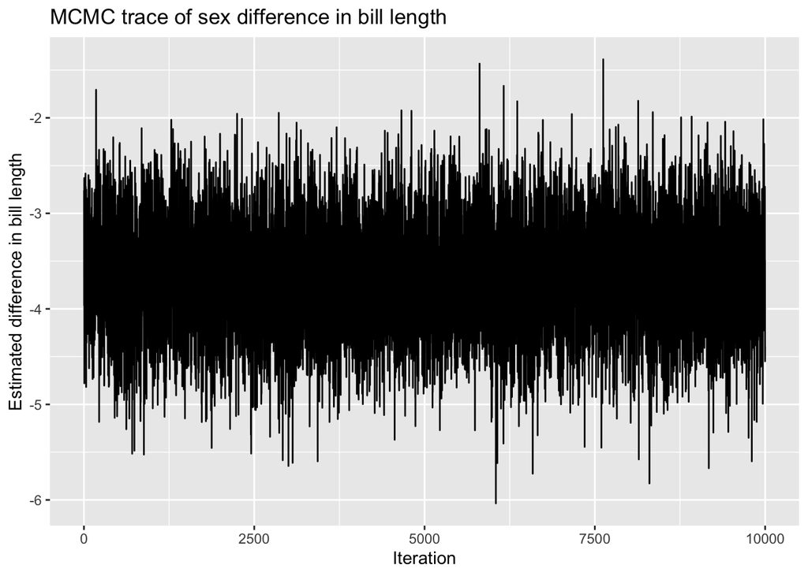

```r
ggplot(data.frame(data = chains[,2]), aes(x = c(1:10000), y = var1)) + geom_line() + ylab("Estimated difference in bill length") + xlab("Iteration") +ggtitle("MCMC trace of sex difference in bill length")
```

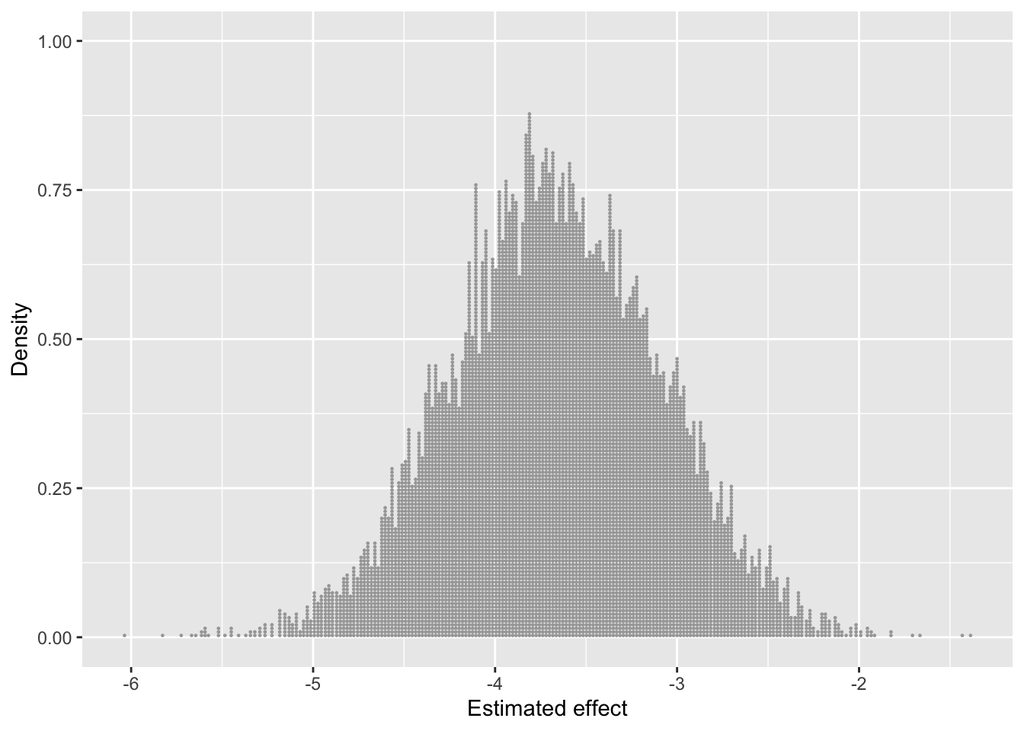

```r
ggplot(data.frame(data = chains[,2]), aes(x = var1)) + geom_dotsinterval(interval_size_domain = c(-5,-2.4)) + xlab("Estimated effect") + ylab("Density")
```